# Impact of Severe Weather Events on Public Health and Economy in the United States

## Synopsis

This is the exploratory analysis of the storm database. The main goal of analysis is to identify the most devastating severe weather event type in terms of public health and economy impact. The original data was collected by the U.S. National Oceanic and Atmospheric Administration’s (NOAA) from 1950 to 2011. We can conclude that over last 60 years of observation more people were killed or injured because of tornado than of any other weather related disaster and flood has the most economic impact.

The major steps of analysis are outlined in the report. More detailed descriptions and code of the functions is located in the end of report

### Load requare libraries and seting working directory

```r
library("data.table")
library("R.utils")

CWD <- "~/Coursera/DataScience/Part5/RepData_PeerAssessment2"
setwd(CWD)
```

### Download and read original data

```r
DataFile <- "./StormData.csv"
CacheData <- read_dataCache( DataFile )
DT <- cacheData(CacheData)
```

## Data Processing

Quick summary of data and counts of each type of events

```r
str(DT)
```

```
## Classes 'data.table' and 'data.frame':   902297 obs. of  37 variables:
##  $ STATE__   : num  1 1 1 1 1 1 1 1 1 1 ...
##  $ BGN_DATE  : chr  "4/18/1950 0:00:00" "4/18/1950 0:00:00" "2/20/1951 0:00:00" "6/8/1951 0:00:00" ...
##  $ BGN_TIME  : chr  "0130" "0145" "1600" "0900" ...
##  $ TIME_ZONE : chr  "CST" "CST" "CST" "CST" ...
##  $ COUNTY    : num  97 3 57 89 43 77 9 123 125 57 ...
##  $ COUNTYNAME: chr  "MOBILE" "BALDWIN" "FAYETTE" "MADISON" ...
##  $ STATE     : chr  "AL" "AL" "AL" "AL" ...
##  $ EVTYPE    : chr  "tornado" "tornado" "tornado" "tornado" ...
##  $ BGN_RANGE : num  0 0 0 0 0 0 0 0 0 0 ...
##  $ BGN_AZI   : chr  "" "" "" "" ...
##  $ BGN_LOCATI: chr  "" "" "" "" ...
##  $ END_DATE  : chr  "" "" "" "" ...
##  $ END_TIME  : chr  "" "" "" "" ...
##  $ COUNTY_END: num  0 0 0 0 0 0 0 0 0 0 ...
```

[output cut: 24 more lines]

```r
DT[,length(INJURIES), by=EVTYPE]
```

```
##                        EVTYPE     V1
##   1:                  tornado  60652
##   2:                tstm wind 219942
##   3:                     hail 288661
##   4:            freezing rain    260
##   5:                     snow    617
##  ---
## 894:          lakeshore flood     23
## 895: marine thunderstorm wind   5812
## 896:       marine strong wind     48
## 897:    astronomical low tide    174
## 898:         volcanic ashfall      3
```

There are more events type than allowed by the event table (page 6). List of allowed events.

```r
ListOfEvents <- c(
                  "Astronomical Low Tide", "Avalanche", "Blizzard", "Coastal Flood",
                  "Cold/Wind Chill", "Debris Flow","Dense Fog", "Dense Smoke",
                  "Drought", "Dust Devil", "Dust Storm", "Excessive Heat", "Hail",
                  "Extreme Cold Wind/Chill", "Flash Flood", "Flood", "Frost Freeze",
                  "Funnel Cloud", "Freezing Fog", "Heat", "Heavy Rain", "Heavy Snow",
                  "High Surf", "High Wind", "Hurricane/Typhoon","Ice Storm", "Lake-Effect Snow",
                  "Lakeshore Flood", "Lightning", "Marine Hail", "Marine High Wind",
                  "Sleet", "Tornado","Marine Strong Wind", "Marine Thunderstorm Wind",
                  "Rip Current", "Seiche", "Storm Surge/Tide", "Strong Wind", "Thunderstorm Wind",
                  "Tropical Depression", "Tropical Storm", "Tsunami", "Volcanic Ash",
                  "Waterspout", "Wildfire", "Winter Storm", "Winter Weather" )
ListOfEvents <- toupper(sort(ListOfEvents, decreasing = F))
print(ListOfEvents)
```

```
##  [1] "ASTRONOMICAL LOW TIDE"    "AVALANCHE"
##  [3] "BLIZZARD"                 "COASTAL FLOOD"
##  [5] "COLD/WIND CHILL"          "DEBRIS FLOW"
##  [7] "DENSE FOG"                "DENSE SMOKE"
##  [9] "DROUGHT"                  "DUST DEVIL"
## [11] "DUST STORM"               "EXCESSIVE HEAT"
## [13] "EXTREME COLD WIND/CHILL"  "FLASH FLOOD"
## [15] "FLOOD"                    "FREEZING FOG"
## [17] "FROST FREEZE"             "FUNNEL CLOUD"
## [19] "HAIL"                     "HEAT"
## [21] "HEAVY RAIN"               "HEAVY SNOW"
## [23] "HIGH SURF"                "HIGH WIND"
## [25] "HURRICANE/TYPHOON"        "ICE STORM"
## [27] "LAKE-EFFECT SNOW"         "LAKESHORE FLOOD"
## [29] "LIGHTNING"                "MARINE HAIL"
## [31] "MARINE HIGH WIND"         "MARINE STRONG WIND"
## [33] "MARINE THUNDERSTORM WIND" "RIP CURRENT"
## [35] "SEICHE"                   "SLEET"
## [37] "STORM SURGE/TIDE"         "STRONG WIND"
## [39] "THUNDERSTORM WIND"        "TORNADO"
## [41] "TROPICAL DEPRESSION"      "TROPICAL STORM"
## [43] "TSUNAMI"                  "VOLCANIC ASH"
## [45] "WATERSPOUT"               "WILDFIRE"
## [47] "WINTER STORM"             "WINTER WEATHER"
```

Event types in the table are formated and aggregated in the proper groups based on the event description. Events without clear description were marked as “other”.

```r
DT <- assign_event_type(DT)
```

In addition, ambiguous event that could be classified in different event types were marked as “other”.

```r
setkey(DT, EVTYPE)
DT[!(EVTYPE %in% ListOfEvents)]$EVTYPE <- "OTHER"
```

## Results

Plotting and summarizing human injury based on event type

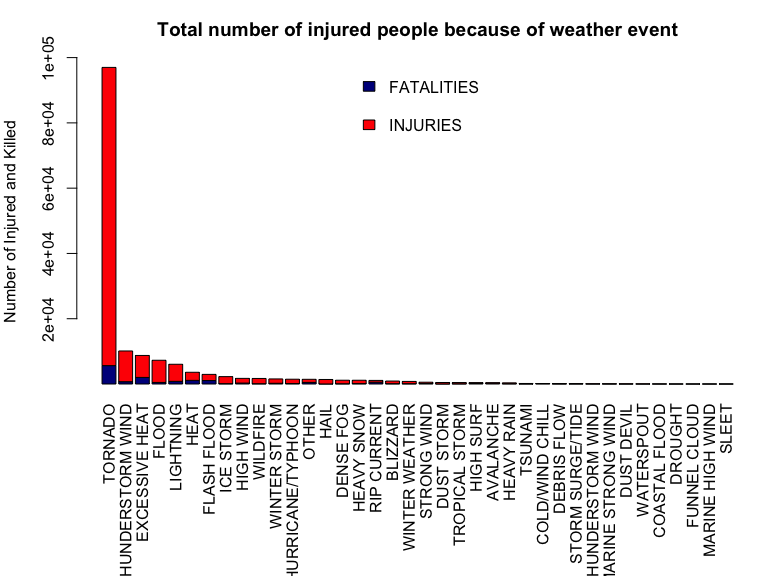

```r
FATALITIES.TOTAL <- aggregate(cbind(FATALITIES, INJURIES)~EVTYPE, data=DT, FUN=sum)
Plot.Matrix <-as.matrix(FATALITIES.TOTAL[,2:3])
rownames(Plot.Matrix) <- FATALITIES.TOTAL$EVTYPE
#sort in decreasing order
Plot.Matrix <- Plot.Matrix[order(Plot.Matrix[,1]+ Plot.Matrix[,2], decreasing = T),]
#drop events with no casualties
Plot.Matrix <- Plot.Matrix[(Plot.Matrix[,2] + Plot.Matrix[,1] > 0),]
#Plot casualties data
par(mar=c(10, 4, 3, 0.5))
barplot(t(Plot.Matrix), main="Total number of injured people because of weather event",
        xlab="", col=c("darkblue","red"), ylab = "Number of Injured and Killed",
         las=3,  ylim=c(1, 100000))
legend("top", bty="n",legend = colnames(Plot.Matrix),
       fill = c("darkblue","red"), y.intersp=2 )
```

### Calculating the damage

```r
DT <- replace_exp_by_number(DT)
DT$PROPDMG <- DT$PROPDMG * DT$PROPDMGEXP
DT$CROPDMG <- DT$CROPDMG * DT$CROPDMGEXP
```

### Summarizing and plotting the economic impact based on event type

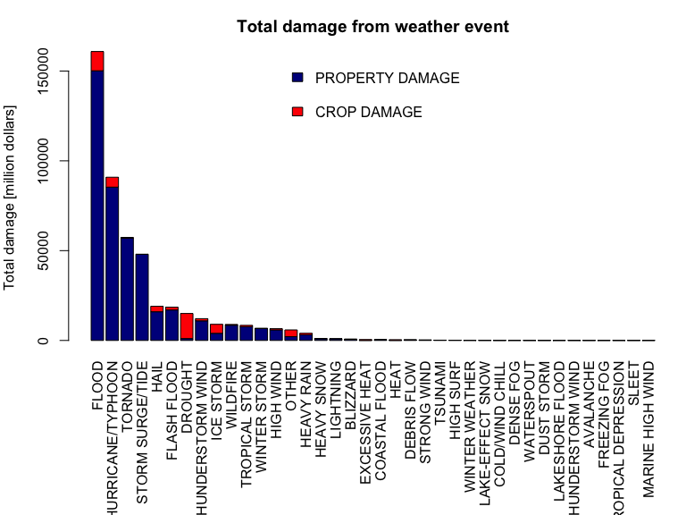

```r
#sum property damage
DAMAGE.TOTAL <- aggregate(cbind(PROPDMG, CROPDMG)~EVTYPE, data=DT, FUN=sum)
Damage.Matrix <-as.matrix(DAMAGE.TOTAL[,2:3])
rownames(Damage.Matrix) <- DAMAGE.TOTAL$EVTYPE
# convert to millions
Damage.Matrix <- Damage.Matrix/1E6
#drop events with damage less then million $
Damage.Matrix <- Damage.Matrix[(Damage.Matrix[,2] + Damage.Matrix[,1] > 1),]
#sort in decreasing order
Damage.Matrix <- Damage.Matrix[order(Damage.Matrix[,1]+Damage.Matrix[,2], decreasing = T),]
#Plot damage data
par(mar=c(10, 4, 3, 0.5))
barplot(t(Damage.Matrix), main="Total damage from weather event",
        xlab="", col=c("darkblue","red"), ylab = "Total damage [million dollars]",
         las=3)
legend("top", bty="n",legend = c("PROPERTY DAMAGE", "CROP DAMAGE"),
       fill = c("darkblue","red"), y.intersp=2)
```

## Code and more detailed description of functions

Read and download data

```r
cacheData <- function(x, ...) {
  DT <- x$get_dt()
  if(!is.null(DT)) {
    return(DT)
  }
  data <- x$get()
  DT <- get_data_helper(File = data,  ...)
  x$set_dt(DT)
  return(DT)
}

read_dataCache <- function(file = character()) {
  DT <- NULL
  set <- function(y) {
    file <<- y
    DT <<- NULL
  }
  get <- function() {file}
  set_dt <- function(dt) {DT <<- dt }
  get_dt <- function() { DT }
  return (list (set = set, get = get,
                set_dt = set_dt, get_dt = get_dt))
}

read_data <- function(File=character()) {
    DT <- fread(input = File)
    DT$EVTYPE <- tolower(DT$EVTYPE) #conver all types to lower case
    return (DT)
}

# Read working file returns data.table. If file is absent in directory downloads it from web
get_data_helper <- function(File = character()) {
    if (file.exists(File) ){
        DT <- read_data(File)
        return ( DT )
    }
    URL <- "https://d396qusza40orc.cloudfront.net/repdata%2Fdata%2FStormData.csv.bz2" # url to data
    DestFile <- paste( File, "bz2", sep = '.')
    download.file(url = URL, destfile = DestFile, quiet = T, method = "curl")
    dataDate <- date()
    cat( sprintf("Data Set was downloaded on %s\n", dataDate))
    bunzip2(DestFile)
    DT <- read_data(File)
    return ( DT )
}
```

Assign event type  
Function assigns types of event try to fix spelling errors and improper naming. Events of unknown types marked as other Some descriptions are ambiguous such event could be marked as events of 2 (or more) types separated by ‘|’  
ALL EVENTS ARE CONVERTED IN UPPERCASE

```r
assign_event_type <- function (DT) {
    # ASTRONOMICAL LOW TIDE
    set(DT, i = grep("astronomical low tide", DT$EVTYPE, ignore.case = F),
        j = 8L, value = "ASTRONOMICAL LOW TIDE")

    # AVALANCHE
    set(DT, i = intersect(grep("avalanche|avalance", DT$EVTYPE, ignore.case = F),
                          grep("snow", DT$EVTYPE, ignore.case = F, invert = T)),
        j = 8L, value = "AVALANCHE")
    set(DT, i = intersect(grep("avalanche|avalance", DT$EVTYPE, ignore.case = F),
                          grep("snow", DT$EVTYPE, ignore.case = F, invert = F)),
        j = 8L, value = "AVALANCHE|BLIZZARD|HEAVY SNOW")

    # BLIZZARD
    set(DT, i = intersect(grep("blizzard", DT$EVTYPE, ignore.case = F),
                          grep("snow|wind|storm", DT$EVTYPE, ignore.case = F, invert = T)),
        j = 8L, value = "BLIZZARD")
    set(DT, i = intersect(grep("blizzard", DT$EVTYPE, ignore.case = F),
                          grep("winter storm", DT$EVTYPE, ignore.case = F, invert = F)),
        j = 8L, value = "BLIZZARD|WINTER STORM")
    set(DT, i = intersect(grep("blizzard", DT$EVTYPE, ignore.case = F),
                          grep("storm", DT$EVTYPE, ignore.case = F, invert = F)),
        j = 8L, value = "BLIZZARD|ICE STORM")
    set(DT, i = intersect(grep("blizzard", DT$EVTYPE, ignore.case = F),
                          grep("freezing rain", DT$EVTYPE, ignore.case = F, invert = F)),
        j = 8L, value = "BLIZZARD|WINTER WEATHER")
    set(DT, i = grep("high wind/wind chill/blizzard", DT$EVTYPE, ignore.case = F),
        j = 8L, value = "BLIZZARD|HIGH WIND|COLD WIND/CHILL")
    set(DT, i = grep("high wind/blizzard/freezing ra", DT$EVTYPE, ignore.case = F),
        j = 8L, value = "BLIZZARD|HIGH WIND|WINTER WEATHER")
    set(DT, i = intersect(grep("blizzard", DT$EVTYPE, ignore.case = F),
                          grep("heavy snow", DT$EVTYPE, ignore.case = F, invert = F)),
        j = 8L, value = "BLIZZARD|HEAVY SNOW")
    set(DT, i = intersect(grep("blizzard", DT$EVTYPE, ignore.case = F),
                          grep("high wind", DT$EVTYPE, ignore.case = F, invert = F)),
        j = 8L, value = "BLIZZARD|HIGH WIND")
    set(DT, i = grep("blizzard and extreme wind chil", DT$EVTYPE, ignore.case = F),
        j = 8L, value = "BLIZZARD|EXTREME COLD/WIND CHILL")

    # COASTAL FLOOD
    set(DT, i = grep("heavy surf coastal flooding", DT$EVTYPE, ignore.case = F),
        j = 8L, value = "COASTAL FLOOD|HIGH SURF")
    set(DT, i = grep("high winds/coastal flood", DT$EVTYPE, ignore.case = F),
        j = 8L, value = "COASTAL FLOOD|HIGH WIND")
    set(DT, i = intersect(grep("flood", DT$EVTYPE, ignore.case = F),
                          grep("coast|cstl|beach", DT$EVTYPE, ignore.case = F, invert = F)),
        j = 8L, value = "COASTAL FLOOD")
    set(DT, i = intersect(grep("flood", DT$EVTYPE, ignore.case = F),
                          grep("tidal", DT$EVTYPE, ignore.case = F, invert = F)),
        j = 8L, value = "COASTAL FLOOD")

    # COLD/WIND CHILL
    set(DT, i = intersect(intersect(grep("chill", DT$EVTYPE, ignore.case = F),
                                    grep("wind", DT$EVTYPE, ignore.case = F, invert = F)),
                          grep("extre|snow|high", DT$EVTYPE, ignore.case = F, invert = T)),
        j = 8L, value = "COLD/WIND CHILL")
    set(DT, i = intersect(intersect(grep("chill", DT$EVTYPE, ignore.case = F),
                                    grep("wind", DT$EVTYPE, ignore.case = F, invert = F)),
                          grep("extre", DT$EVTYPE, ignore.case = F, invert = F)),
        j = 8L, value = "EXTREME COLD/WIND CHILL")
    set(DT, i = intersect(grep("chill", DT$EVTYPE, ignore.case = F),
                          grep("wind", DT$EVTYPE, ignore.case = F, invert = F)),
        j = 8L, value = "COLD/WIND CHILL|HIGH WIND")
    set(DT, i = grep("cold/winds|unusually cold|cold wave|prolong cold|cold weather", DT$EVTYPE, ignore.case = F),
        j = 8L, value = "COLD/WIND CHILL")
    set(DT, i = grep("high winds/cold", DT$EVTYPE, ignore.case = F),
        j = 8L, value = "COLD/WIND CHILL|HIGH WIND")
    set(DT, i = grep("unusually cold|cold temperat|unseasonable cold|unseasonably cold", DT$EVTYPE, ignore.case = F),
        j = 8L, value = "COLD/WIND CHILL")

    #DEBRIS FLOW
    set(DT, i = intersect(grep("slide", DT$EVTYPE, ignore.case = F),
                          grep("flood", DT$EVTYPE, ignore.case = F, invert = T)),
        j = 8L, value = "DEBRIS FLOW")
    set(DT, i = grep("heavy rain/mudslides/flood", DT$EVTYPE, ignore.case = F),
        j = 8L, value = "DEBRIS FLOW|FLOOD|HEAVY RAIN")
    set(DT, i = intersect(grep("slide", DT$EVTYPE, ignore.case = F),
                          grep("flood", DT$EVTYPE, ignore.case = F, invert = F)),
        j = 8L, value = "DEBRIS FLOW|FLASH FLOOD")

    #DENSE FOG
    set(DT, i = intersect(grep("fog|dense fog|vog", DT$EVTYPE, ignore.case = F),
                          grep("cold|ice|freez", DT$EVTYPE, ignore.case = F, invert = T)),
        j = 8L, value = "DENSE FOG")
    set(DT, i = intersect(grep("fog", DT$EVTYPE, ignore.case = F),
                          grep("cold|ice|freez", DT$EVTYPE, ignore.case = F, invert = F)),
        j = 8L, value = "FREEZING FOG")

    #DENSE SMOKE
    set(DT, i = grep("smoke", DT$EVTYPE, ignore.case = F),
        j = 8L, value = "DENSE SMOKE")

    #DROUGHT
    set(DT, i = intersect(grep("drought|driest month", DT$EVTYPE, ignore.case = F),
                          grep("heat", DT$EVTYPE, ignore.case = F, invert = T)),
        j = 8L, value = "DROUGHT")
    set(DT, i = intersect(grep("drought", DT$EVTYPE, ignore.case = F),
                          grep("excessive heat", DT$EVTYPE, ignore.case = F, invert = F)),
        j = 8L, value = "DROUGHT|EXCESSIVE HEAT")
    set(DT, i = grep("drought", DT$EVTYPE, ignore.case = F),
        j = 8L, value = "DROUGHT|HEAT")
    set(DT, i = grep("drynes|dry weatheri|lack of snow|abnormally dry|below normal precipitation", DT$EVTYPE, ignore.case = F),
        j = 8L, value = "DROUGHT")
```

```r
    #DUST DEVIL
    set(DT,i = intersect(grep("dust devil|landspout|whirlwind", DT$EVTYPE, ignore.case = F),
                         grep("waterspout", DT$EVTYPE, ignore.case = F, invert = T)) ,
        j = 8L, value = "DUST DEVIL")
    set(DT,i = intersect(grep("dust devil", DT$EVTYPE, ignore.case = F),
                         grep("waterspout", DT$EVTYPE, ignore.case = F, invert = F)) ,
        j = 8L, value = "DUST DEVIL|WATERSPOUT")

    #DUST STORM
    set(DT,i = grep("dust", DT$EVTYPE, ignore.case = F),
        j = 8L, value = "DUST STORM")

    #EXCESSIVE HEAT
    set(DT,i = intersect(grep("heat", DT$EVTYPE, ignore.case = F),
                         grep("excessive|extre|record", DT$EVTYPE, ignore.case = F, invert = F)) ,
        j = 8L, value = "EXCESSIVE HEAT")

    #EXTREME COLD/WIND CHILL
    set(DT, i = grep("record cold and high wind", DT$EVTYPE, ignore.case = F),
        j = 8L, value = "EXTREME COLD/WIND CHILL|HIGH WIND")
    set(DT, i = grep("record snow/cold", DT$EVTYPE, ignore.case = F),
        j = 8L, value = "EXTREME COLD/WIND CHILL|HEAVY SNOW")
    set(DT, i = intersect(grep("cold", DT$EVTYPE, ignore.case = F),
                          grep("extreme|record|severe|extended|excessive", DT$EVTYPE, ignore.case = F, invert = F)),
        j = 8L, value = "EXTREME COLD/WIND CHILL")

    #FLASH FLOOD AND FLOOD
    set(DT, i = intersect(intersect(grep("flood|floood", DT$EVTYPE, ignore.case = F),
                                    grep("flash|minor|ice jam|breakup|local", DT$EVTYPE, ignore.case = F, invert = F)),
                          grep("rain|wind|storm", DT$EVTYPE, ignore.case = F, invert = T)),
        j = 8L, value = "FLASH FLOOD")
    set(DT, i = intersect(intersect(grep("flood", DT$EVTYPE, ignore.case = F),
                                    grep("flash|urban", DT$EVTYPE, ignore.case = F, invert = F)),
                          grep("thunder", DT$EVTYPE, ignore.case = F, invert = F)),
        j = 8L, value = "FLASH FLOOD|THUNDERSTORM WIND")
    set(DT, i = grep("thunderstorm winds/ flood|thunderstorm winds/flooding", DT$EVTYPE, ignore.case = F),
        j = 8L, value = "FLOOD|THUNDERSTORM WIND")
    set(DT, i = intersect(grep("flash flood", DT$EVTYPE, ignore.case = F),
                          grep("heavy rain", DT$EVTYPE, ignore.case = F, invert = F)),
        j = 8L, value = "FLASH FLOOD|HEAVY RAIN")
    set(DT, i = intersect(grep("flood|small stream urban", DT$EVTYPE, ignore.case = F),
                          grep("heavy rain", DT$EVTYPE, ignore.case = F, invert = F)),
        j = 8L, value = "FLOOD|HEAVY RAIN")
    set(DT, i = grep("flash flood winds|small stream flood|ice jam|high water|rapidly rising water", DT$EVTYPE, ignore.case = F),
        j = 8L, value = "FLASH FLOOD")
    set(DT, i = intersect(grep("flood", DT$EVTYPE, ignore.case = F),
                          grep("river|urban|watch|major|snowmelt|street|highway|rural|stream", DT$EVTYPE, ignore.case = F, invert = F)),
        j = 8L, value = "FLOOD")
    set(DT, i = intersect(grep("flood", DT$EVTYPE, ignore.case = F),
                          grep("lake", DT$EVTYPE, ignore.case = F, invert = F)),
        j = 8L, value = "LAKESHORE FLOOD")
    set(DT, i = grep("heavy snow/high winds & flood", DT$EVTYPE, ignore.case = F),
        j = 8L, value = "FLOOD|HEAVY SNOW|HIGH WIND")
    set(DT, i = intersect(grep("flood", DT$EVTYPE, ignore.case = F),
                          grep("wind", DT$EVTYPE, ignore.case = F, invert = F)),
        j = 8L, value = "FLOOO|HIGH WIND")
    set(DT, i = intersect(grep("flood", DT$EVTYPE, ignore.case = F),
                          grep("hail", DT$EVTYPE, ignore.case = F, invert = F)),
        j = 8L, value = "FLASH FLOOO|HAIL")
    set(DT, i = intersect(grep("flood", DT$EVTYPE, ignore.case = F),
                          grep("ice", DT$EVTYPE, ignore.case = F, invert = F)),
        j = 8L, value = "FLASH FLOOO|ICE STORM")
    set(DT, i = grep("flood", DT$EVTYPE, ignore.case = F),
        j = 8L, value = "FLOOD")
    set(DT, i = grep("urban/sml stream fld", DT$EVTYPE, ignore.case = F),
        j = 8L, value = "FLASH FLOOD")

    #FROST/FREEZE
    set(DT,  i = intersect(grep("frost|freez", DT$EVTYPE, ignore.case = F),
                           grep("rain|snow|driz|spray", DT$EVTYPE, ignore.case = F, invert = T)),
        j = 8L, value = "FROST/FREEZE")
    set(DT,  i = intersect(grep("frost|freez", DT$EVTYPE, ignore.case = F),
                           grep("snow|sleet", DT$EVTYPE, ignore.case = F, invert = T)),
        j = 8L, value = "FROST/FREEZE|ICE STORM")
    set(DT, i = intersect(grep("frost|freez", DT$EVTYPE, ignore.case = F),
                          grep("heavy|sleet", DT$EVTYPE, ignore.case = F, invert = T)),
        j = 8L, value = "ICE STORM")

    #FUNNEL CLOUD
    set(DT, i = intersect(grep("funnel|turbulence", DT$EVTYPE, ignore.case = F),
                          grep("hail|thunder|water", DT$EVTYPE, ignore.case = F, invert = T)),
        j = 8L, value = "FUNNEL CLOUD")
    set(DT, i = intersect(grep("funnel", DT$EVTYPE, ignore.case = F),
                          grep("thunder", DT$EVTYPE, ignore.case = F, invert = F)),
        j = 8L, value = "FUNNEL CLOUD|THUNDERSTORM WINDS")
    set(DT, i = intersect(grep("funnel", DT$EVTYPE, ignore.case = F),
                          grep("hail", DT$EVTYPE, ignore.case = F, invert = F)),
        j = 8L, value = "FUNNEL CLOUD|HAIL")
    set(DT, i = intersect(grep("funnel", DT$EVTYPE, ignore.case = F),
                          grep("waterspout", DT$EVTYPE, ignore.case = F, invert = F)),
        j = 8L, value = "FUNNEL CLOUD|WATERSPOUT")

    #FREEZING FOG

    #HAIL
    set(DT, i = intersect(grep("hail", DT$EVTYPE, ignore.case = F),
                          grep("marine|thunder|wind", DT$EVTYPE, ignore.case = F, invert = T)),
        j = 8L, value = "HAIL")
    set(DT, i = grep("tornadoes, tstm wind, hail", DT$EVTYPE, ignore.case = F),
        j = 8L, value = "HAIL|THUNDERSTORM WIND|TORNADO")
    set(DT, i = grep("marine hail", DT$EVTYPE, ignore.case = F),
        j = 8L, value = "MARINE HAIL")
    set(DT, i = intersect(grep("hail", DT$EVTYPE, ignore.case = F),
                          grep("thunder|tstm", DT$EVTYPE, ignore.case = F, invert = F)),
        j = 8L, value = "HAIL|THUNDERSTORM WIND")
    set(DT, i = intersect(grep("hail", DT$EVTYPE, ignore.case = F),
                          grep("wind", DT$EVTYPE, ignore.case = F, invert = F)),
        j = 8L, value = "HAIL|STRONG WIND")
```

```r
    #HEAT
    set(DT, i = grep("heat", DT$EVTYPE, ignore.case = F),
        j = 8L, value = "HEAT")

    #HEAVY RAIN
    set(DT,i = intersect(grep("heavy rain|heavy shower", DT$EVTYPE, ignore.case = F),
                         grep("wind|snow|ligh|tstm|surf|stream", DT$EVTYPE, ignore.case = F, invert = T)) ,
        j = 8L, value = "HEAVY RAIN")
    set(DT,i = intersect(grep("heavy rain", DT$EVTYPE, ignore.case = F),
                         grep("ligh", DT$EVTYPE, ignore.case = F, invert = F)) ,
        j = 8L, value = "HEAVY RAIN|LIGHTNING")
    set(DT,i = intersect(grep("heavy rain", DT$EVTYPE, ignore.case = F),
                         grep("tstm|thunde", DT$EVTYPE, ignore.case = F, invert = F)) ,
        j = 8L, value = "HEAVY RAIN|THUNDERSTORM WIND")
    set(DT,i = intersect(grep("heavy rain", DT$EVTYPE, ignore.case = F),
                         grep("wind", DT$EVTYPE, ignore.case = F, invert = F)) ,
        j = 8L, value = "HEAVY RAIN|HIGH WIND")
    set(DT, i = grep("heavy rain/high surf", DT$EVTYPE, ignore.case = F),
        j = 8L, value = "HEAVY RAIN|HIGH SURF")
    set(DT, i = grep("heavy rain/snow", DT$EVTYPE, ignore.case = F),
        j = 8L, value = "HEAVY RAIN|HEAVY SNOW")

    #HEAVY SNOW
    set(DT,i = intersect(grep("heavy snow", DT$EVTYPE, ignore.case = F),
                         grep("high wind", DT$EVTYPE, ignore.case = F, invert = F)) ,
        j = 8L, value = "HEAVY SNOW|HIGH WIND")
    set(DT,i = intersect(grep("heavy snow", DT$EVTYPE, ignore.case = F),
                         grep("wind", DT$EVTYPE, ignore.case = F, invert = F)) ,
        j = 8L, value = "HEAVY SNOW|STRONG WIND")
    set(DT,i = intersect(grep("heavy snow", DT$EVTYPE, ignore.case = F),
                         grep("ice|freez", DT$EVTYPE, ignore.case = F, invert = F)) ,
        j = 8L, value = "HEAVY SNOW|ICE STORM")
    set(DT,i = intersect(grep("heavy snow", DT$EVTYPE, ignore.case = F),
                         grep("winter", DT$EVTYPE, ignore.case = F, invert = F)) ,
        j = 8L, value = "HEAVY SNOW|WINTER STORM")
    set(DT,i = intersect(grep("heavy snow", DT$EVTYPE, ignore.case = F),
                         grep("sleet", DT$EVTYPE, ignore.case = F, invert = F)) ,
        j = 8L, value = "HEAVY SNOW|SLEET")
    set(DT, i = grep("heavy lake snow", DT$EVTYPE, ignore.case = F),
        j = 8L, value = "LAKE-EFFECT SNOW")
    set(DT,i = intersect(grep("heavy|winter|snowfall", DT$EVTYPE, ignore.case = F),
                         grep("snow", DT$EVTYPE, ignore.case = F, invert = F)) ,
        j = 8L, value = "HEAVY SNOW")

    #HIGH SURF
    set(DT,i = intersect(grep("surf|high tide|heavy seas|high seas|high waves|rogue", DT$EVTYPE, ignore.case = F),
                         grep("rip", DT$EVTYPE, ignore.case = F, invert = T)),
        j = 8L, value = "HIGH SURF")
    set(DT,i = intersect(grep("surf", DT$EVTYPE, ignore.case = F),
                         grep("rip", DT$EVTYPE, ignore.case = F, invert = F)),
        j = 8L, value = "HIGH SURF|RIP CURRENT")

    #HIGH WIND
    set(DT,i = intersect(grep("high wind", DT$EVTYPE, ignore.case = F),
                         grep("winter|snow", DT$EVTYPE, ignore.case = F, invert = F)),
        j = 8L, value = "HIGH WIND|WINTER STORM")
    set(DT,i = intersect(grep("high wind", DT$EVTYPE, ignore.case = F),
                         grep("marine", DT$EVTYPE, ignore.case = F, invert = F)),
        j = 8L, value = "MARINE HIGH WIND")
    set(DT,i = intersect(grep("high wind", DT$EVTYPE, ignore.case = F),
                         grep("tides|seas", DT$EVTYPE, ignore.case = F, invert = F)),
        j = 8L, value = "HIGH WIND|STORM SURGE/TIDE")
    set(DT,i = intersect(grep("high wind", DT$EVTYPE, ignore.case = F),
                         grep("hurricane", DT$EVTYPE, ignore.case = F, invert = F)),
        j = 8L, value = "HURRICANE/TYPHOON")
    set(DT,i = intersect(grep("high", DT$EVTYPE, ignore.case = F),
                         grep("wind", DT$EVTYPE, ignore.case = F, invert = F)),
        j = 8L, value = "HIGH WIND")

    #HURRICANE/TYPHOON
    set(DT, i = grep("hurr|typ", DT$EVTYPE, ignore.case = F),
        j = 8L, value = "HURRICANE/TYPHOON")

    #ICE STORM
    set(DT, i = grep("ice/strong winds", DT$EVTYPE, ignore.case = F),
        j = 8L, value = "ICE STORM|STRONG WIND")
    set(DT, i = grep("ice|sleet storm", DT$EVTYPE, ignore.case = F),
        j = 8L, value = "ICE STORM")

    #LAKE-EFFECT SNOW
    set(DT,i = intersect(grep("lake", DT$EVTYPE, ignore.case = F),
                         grep("snow", DT$EVTYPE, ignore.case = F, invert = F)),
        j = 8L, value = "LAKE-EFFECT SNOW")

    #LAKESHORE FLOOD

    #LIGHTNING
    set(DT,i = intersect(grep("lightn|lighti|ligntning", DT$EVTYPE, ignore.case = F),
                         grep("thun|tstm", DT$EVTYPE, ignore.case = F, invert = T)),
        j = 8L, value = "LIGHTNING")
    set(DT,i = intersect(grep("lightn|lighti", DT$EVTYPE, ignore.case = F),
                         grep("thun|tstm", DT$EVTYPE, ignore.case = F, invert = F)),
        j = 8L, value = "LIGHTNING|THUNDERSTORM WIND")

    #MARINE HAIL

    #MARINE HIGH WIND
    set(DT, i = grep("marine accident", DT$EVTYPE, ignore.case = F),
        j = 8L, value = "STORM SURGE/TIDE")

    #MARINE STRONG WIND
    set(DT,i = intersect(grep("marine", DT$EVTYPE, ignore.case = F),
                         grep("strong|mishap", DT$EVTYPE, ignore.case = F, invert = F)),
        j = 8L, value = "MARINE STRONG WIND")

    #MARINE THUNDERSTORM WIND
    set(DT,i = intersect(grep("marine", DT$EVTYPE, ignore.case = F),
                         grep("tstm|thund", DT$EVTYPE, ignore.case = F, invert = F)),
        j = 8L, value = "MARINE THUNDERSTORM WIND")

    #RIP CURRENT
    set(DT,i = grep("rip", DT$EVTYPE, ignore.case = F),
        j = 8L, value = "RIP CURRENT")

    #SEICHE
    set(DT,i = grep("seiche", DT$EVTYPE, ignore.case = F),
        j = 8L, value = "SEICHE")

    #SLEET
    set(DT,i = grep("sleet", DT$EVTYPE, ignore.case = F),
        j = 8L, value = "SLEET")
```

```r
    #STORM SURGE/TIDE
    set(DT,i = grep("surge|coastalstorm|coastal storm|rough seas|wind and wave", DT$EVTYPE, ignore.case = F),
        j = 8L, value = "STORM SURGE/TIDE")

    #STRONG WIND
    set(DT,i = intersect(grep("strong|gusty", DT$EVTYPE, ignore.case = F),
                         grep("rain|thund", DT$EVTYPE, ignore.case = F, invert = T)),
        j = 8L, value = "STRONG WIND")
    set(DT,i = intersect(grep("strong|gusty", DT$EVTYPE, ignore.case = F),
                         grep("rain", DT$EVTYPE, ignore.case = F, invert = F)),
        j = 8L, value = "HEAVY RAIN|STRONG WIND")
    set(DT,i = intersect(grep("strong|gusty", DT$EVTYPE, ignore.case = F),
                         grep("thund", DT$EVTYPE, ignore.case = F, invert = F)),
        j = 8L, value = "STRONG WIND|THUNDERSTORM WIND")

    #THUNDERSTORM WIND
    set(DT,i = intersect(grep("thund|tst|thunerstorm|thuderstorm|tunderstorm", DT$EVTYPE, ignore.case = F),
                         grep("non", DT$EVTYPE, ignore.case = F, invert = T)),
        j = 8L, value = "THUNDERSTORM WIND")
    set(DT,i = intersect(grep("thund|tst", DT$EVTYPE, ignore.case = F),
                         grep("non", DT$EVTYPE, ignore.case = F, invert = F)),
        j = 8L, value = "HIGH WIND")

    #TORNADO
    set(DT,i = intersect(grep("tornado|torndao", DT$EVTYPE, ignore.case = F),
                         grep("water", DT$EVTYPE, ignore.case = F, invert = T)),
        j = 8L, value = "TORNADO")
    set(DT,i = intersect(grep("tornado", DT$EVTYPE, ignore.case = F),
                         grep("water", DT$EVTYPE, ignore.case = F, invert = F)),
        j = 8L, value = "TORNADO|WATERSPOUT")

    #TROPICAL DEPRESSION
    set(DT,i = grep("tropical depression", DT$EVTYPE, ignore.case = F),
        j = 8L, value = "TROPICAL DEPRESSION")

    #TROPICAL STORM
    set(DT,i = grep("tropical storm", DT$EVTYPE, ignore.case = F),
        j = 8L, value = "TROPICAL STORM")

    #TSUNAMI
    set(DT,i = grep("tsunami", DT$EVTYPE, ignore.case = F),
        j = 8L, value = "TSUNAMI")

    #VOLCANIC ASH
    set(DT,i = grep("ash|volcanic", DT$EVTYPE, ignore.case = F),
        j = 8L, value = "VOLCANIC ASH")

    #WATERSPOUT
    set(DT,i = grep("spout", DT$EVTYPE, ignore.case = F),
        j = 8L, value = "WATERSPOUT")

    #WILDFIRE
    set(DT,i = grep("fire", DT$EVTYPE, ignore.case = F),
        j = 8L, value = "WILDFIRE")

    #WINTER STORM
    set(DT,i = intersect(grep("winter", DT$EVTYPE, ignore.case = F),
                         grep("storm", DT$EVTYPE, ignore.case = F, invert = F)),
        j = 8L, value = "WINTER STORM")

    #WINTER WEATHER
    set(DT,i = grep("winter|wint|light snow|accumulated snowfal|snow", DT$EVTYPE, ignore.case = F),
        j = 8L, value = "WINTER WEATHER")

    #RANDOM WIND MARKED AS STRONG WIND
    set(DT,i = grep("wind", DT$EVTYPE, ignore.case = F),
        j = 8L, value = "STRONG WIND")

    #MARK THE REST AS OTHER
    set(DT,i = grep("[a-z]", DT$EVTYPE, ignore.case = F, perl = T),
        j = 8L, value = "OTHER")

    return (DT)
}
```

Calculating damage  
Replace exponent from letter to numeric number allowed exponents H=1E2, K=1E3, M=1E6, B=1E9, the rest are replaced by 1

```r
replace_exp_by_number <- function (DT) {
    DT[!(DT$PROPDMGEXP%in%c('k', 'K', 'm', 'M', 'b', 'B', 'h', 'H'))]$PROPDMGEXP <- '1'
    DT[ (DT$PROPDMGEXP%in%c('h', 'H'))]$PROPDMGEXP <- "1E2"
    DT[ (DT$PROPDMGEXP%in%c('k', 'K'))]$PROPDMGEXP <- "1E3"
    DT[ (DT$PROPDMGEXP%in%c('m', 'M'))]$PROPDMGEXP <- "1E6"
    DT[ (DT$PROPDMGEXP%in%c('b', 'B'))]$PROPDMGEXP <- "1E9"
    DT$PROPDMGEXP <- as.numeric(DT$PROPDMGEXP)
    DT[!(DT$CROPDMGEXP%in%c('k', 'K', 'm', 'M', 'b', 'B', 'h', 'H'))]$CROPDMGEXP <- "1"
    DT[ (DT$CROPDMGEXP%in%c('h', 'H'))]$CROPDMGEXP <- "1E2"
    DT[ (DT$CROPDMGEXP%in%c('k', 'K'))]$CROPDMGEXP <- "1E3"
    DT[ (DT$CROPDMGEXP%in%c('m', 'M'))]$CROPDMGEXP <- "1E6"
    DT[ (DT$CROPDMGEXP%in%c('b', 'B'))]$CROPDMGEXP <- "1E9"
    DT$CROPDMGEXP <- as.numeric(DT$CROPDMGEXP)
    return (DT)
}
```